# Child Doc 6: qPCR Data

Grace Rubin

2025-01-20

## 3.a. Overview

The main purpose of qPCR in MFC2 was to:

1. broadly verify that our antibiotic cocktail successfully suppressed gut microbial density
2. quantify the extent of that suppression. By what order of magnitude did ABX and non-ABX groups differ in bacterial density?
- Our qPCR DF includes measurements of genomes per gram of feces. These values can differ by several orders of magnitude between the ABX and non-ABX mice, making it difficult to visualize them on the same plot. To help us better compare their differences, let’s add a new column with the log-transformed values.

## 3.a.i. Longitudinal changes in bacterial density in ABX and Non-ABX groups over time

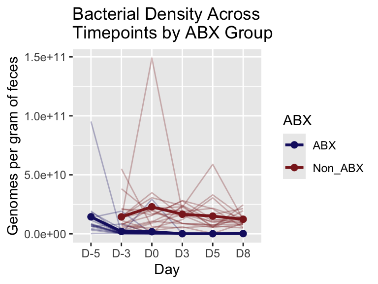

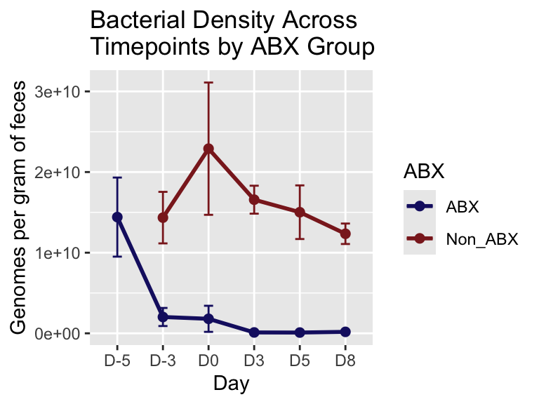

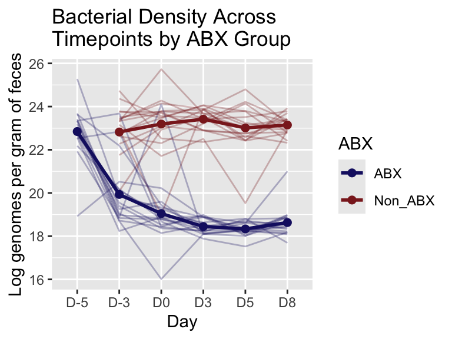

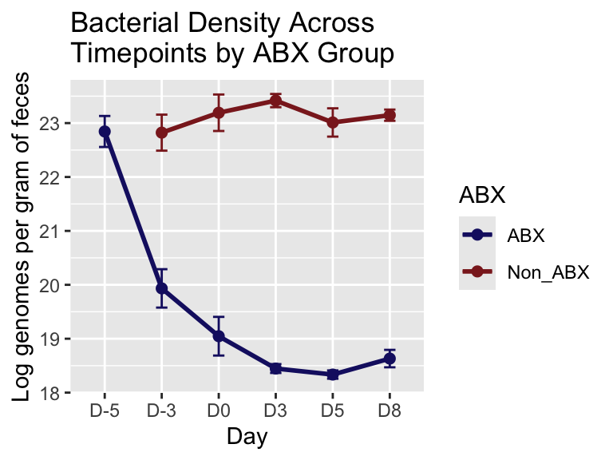

## 3.a.ii. Endpoint differences in bacterial density between ABX and Non-ABX

First I’m going to include all ABX days (D-3 to D8):

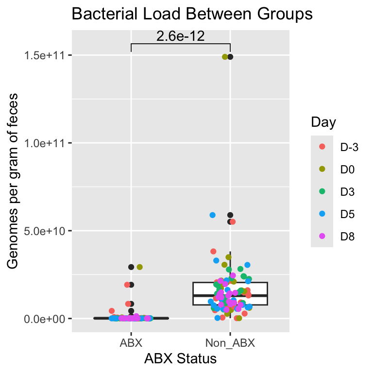

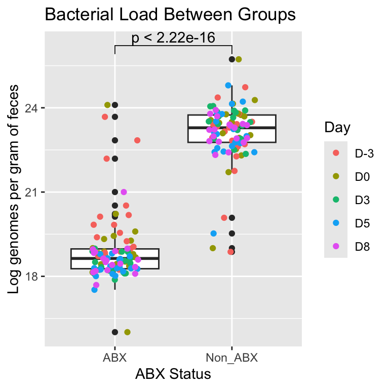

Next, to look at endpoint, we can include just days 5 and day 8, when we expect bacterial density to be maximally suppressed in the ABX mice:

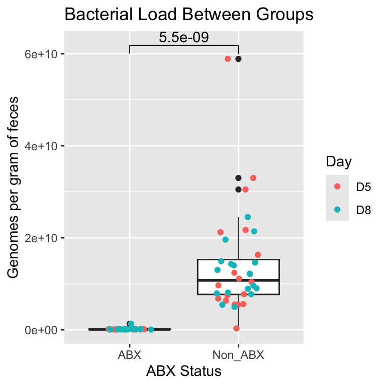

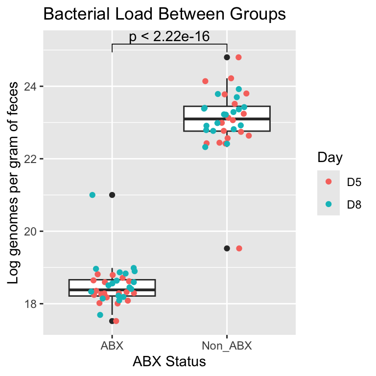

## 3.a.iii. Assessing any hormone-based differences in bacterial density

### Longitudinal group differences?

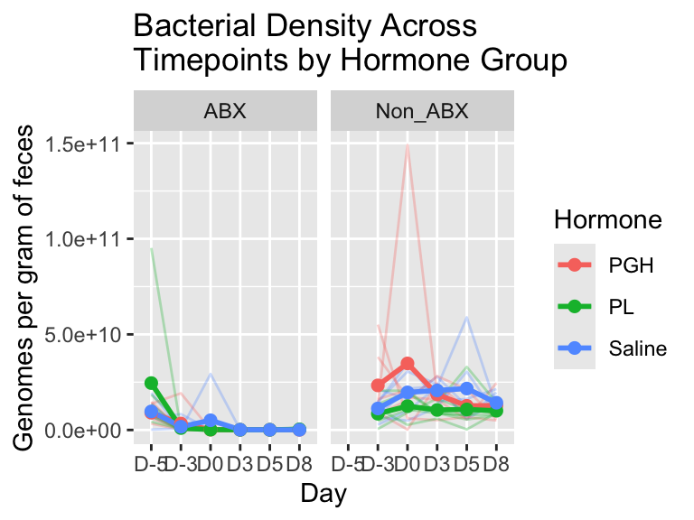

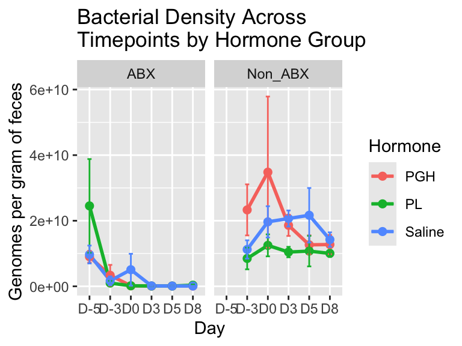

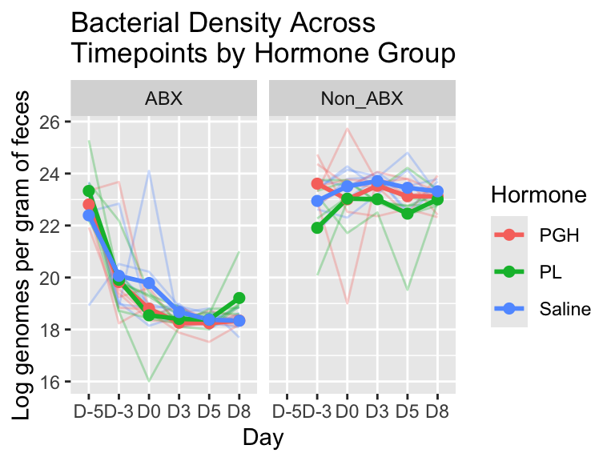

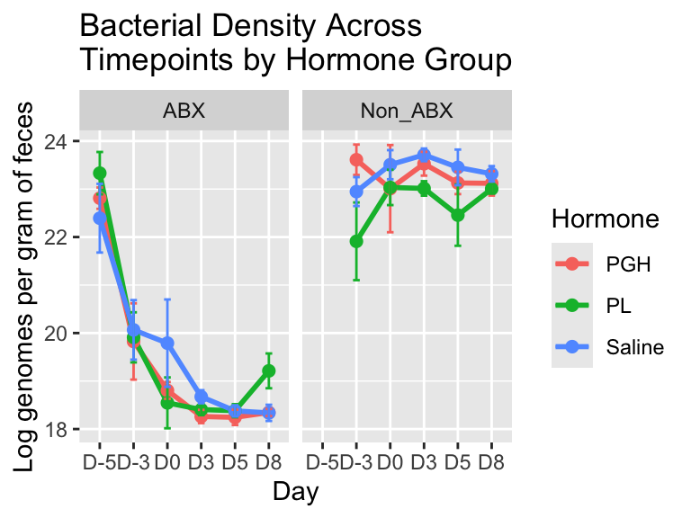

### Endpoint group differences?

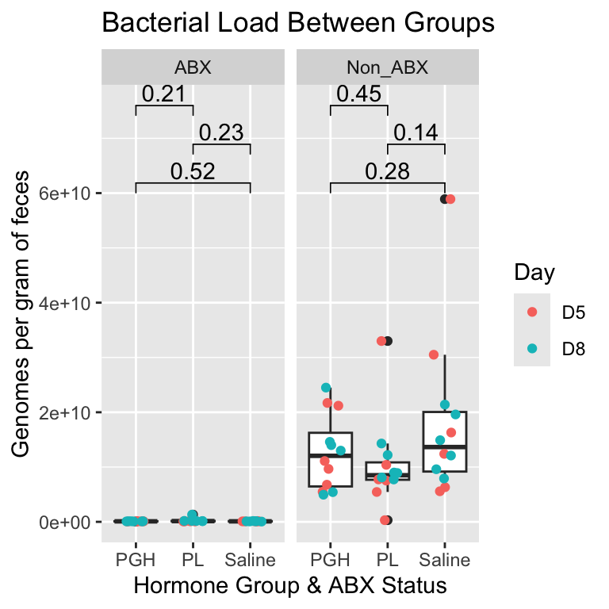

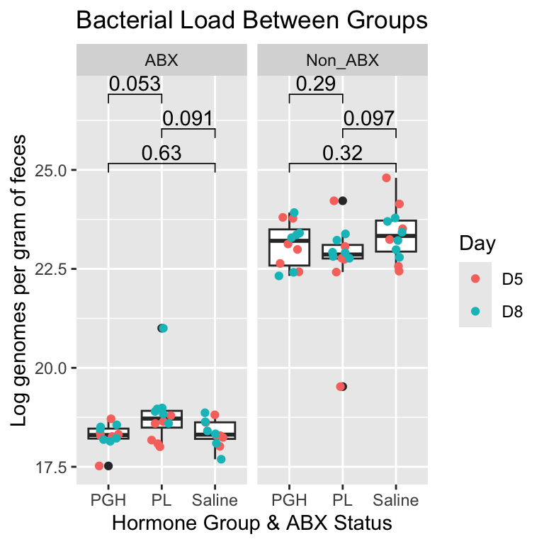

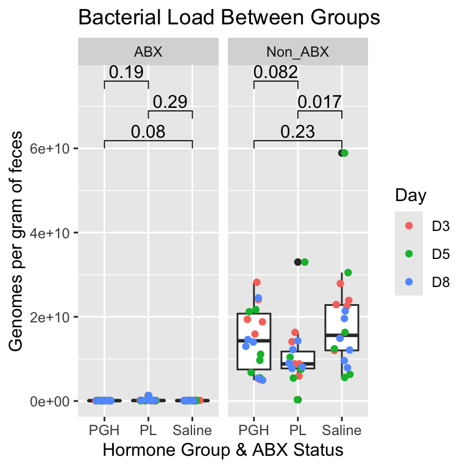

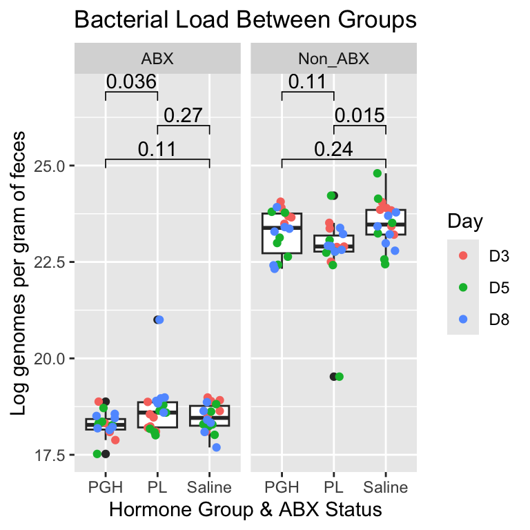

There is lower bacterial density in the PL Non-ABX mice than in the Saline Non-ABX mice when all antibiotic hormone days are included (D3, D5, and D8). However, this difference doesn’t reach significance when only days 5 and 8 are included. Additionally, as we can see from the longitudinal analyses, it appears that prior to any hormone exposure, the mice in the PL group had naturally lower fecal bacterial loads.